# HuberMokate_28April

# Graph

Pivot columns for graph

```r
# Here, we remove unnecessary columns and pivot longer to facilitate graphing
# our data

main_dataset_final <-
  main_dataset %>%
  pivot_longer(cols = c(raw_min_wage,
                        min_wage_2018_adjusted,
                        min_wage_prod_adjusted,
                        min_wage_purchasing_power),
               names_to = "Type",
               values_to = "Dollars") %>%
  select(year, "Type", "Dollars") # only want several columns relevant for the graph
```

## Create a theme

We create a theme will the following qualities:

1. Includes the minimal theme included in R
2. Assigns the Georgia font to graph text
3. Specifies that the title is bold, size 16, and seagreen
4. Specifies that the subtitle is italic, size 14, and royalblue4
5. Specifies that the axis text is size 12 and navyblue
6. Eliminate axis lines and ticks
7. Rotate x axis values 90 degrees so that entire value is visible and axis is cleaner
8. Specifies that the legend title is bold, size 12, and seagreen
9. Specifies that the legend text is size 12 and navyblue

```r
wage_theme <-
  theme_minimal() +
  theme(
    text = element_text(family = "Georgia"),
    plot.title = element_text(face = "bold", size = 16, color = "seagreen"),
    plot.subtitle = element_text(face = "italic", size = 14, color = "royalblue4"),
    axis.title = element_text(size = 14, face = "bold", color = "seagreen"),
    axis.text = element_text(size = 12, color = "navyblue"),
    axis.line = element_blank(),
    axis.ticks = element_blank(),
    axis.text.x = element_text(angle = 90),
    legend.title = element_text(size = 12, face = "bold", color = "seagreen"),
    legend.text = element_text(size = 12, color = "navyblue"))
```

Create column in un-pivoted dataset to identify years that the minimum wage changed

```r
# need to create the column with the specified type and length
main_dataset$wage_change <- vector("numeric", nrow(main_dataset))

# loops through rows in main_dataset and returns 0 if they did not change from the previous year (row) and 45 if they did change
for (i in seq(nrow(main_dataset))) {
  if (i == 1) {
    main_dataset$wage_change[i] <- 0
  } else {
    if (main_dataset$raw_min_wage[i] == main_dataset$raw_min_wage[i - 1]) {
    main_dataset$wage_change[i] <- 0 # do not want these values to show up when graphed
    }
    else {
    main_dataset$wage_change[i] <- 45 # assign value of 45 so that it will align with our other graph when mapped
    }
  }
}
```

## Create Graph to show changed the different minimum wage values that we calculated as well as raw minimum wage

Create two parts of the graph: year when minimum wage changed as a background bar graph with high transparency and a line graph for the various minimum wage values

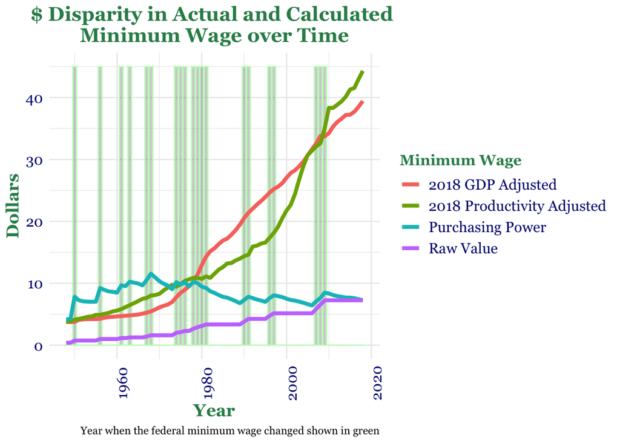

## Interpret Graph

As discussed in the overview, the current discussions surrounding minimum wage increases are very polarizing, with impassioned beliefs of pros and cons from proponents and opponents of the measure. Key arguments made against raising minimum wage are that the increase could lead to inflation and job losses, and negatively impact businesses. Conversely, proponents raise points about the increased costs of living and claim that the current rate is not sufficient income.

### Purchasing Power Versus Raw Value:

These metrics highlight that minimum wage over time has failed to keep pace with the economic factors of productivity and purchasing power.

### Years with Changes in Federal Minimum Wage

# Table

```r
# Add in president data pulled in earlier
# This helps us to provide some analysis of what administrations increased wages for context, referenced in our interpretation of our chart
p1 <-
  left_join(main_dataset, presidents)

p2 <- p1 %>%
  fill(president, .direction = "up") %>%
  fill(party, .direction = "up") # ensure that all years have party and president values, not just start and end years

wage_with_pres <- p2[!duplicated(p2$year, fromLast = T), ] # clear out any duplicated years by taking the last value of that year
```

Here, we want a table that shows all of our calculated values in years where Congress adjusted the minimum wage

```r
# Create table data; we want to narrow down
table_dataset <-
  left_join(wage_with_pres, min_wage_dataset) %>%
  filter(wage_change == 45) %>%
  filter(year >= 1948) %>%
  select(year,
         president,
         raw_min_wage,
         min_wage_purchasing_power,
         min_wage_2018_adjusted,
         min_wage_prod_adjusted) %>%
  mutate("Number of Years Since Last Change" = year - lag(year, default = first(year))) %>% # calculate how long it has been since the last increase in minimum wage
  mutate(year = as.character(year))

# Convert all dollar values to currency type
table_dataset$raw_min_wage <- currency(table_dataset$raw_min_wage, digits = 2L)
table_dataset$min_wage_purchasing_power <- currency(table_dataset$min_wage_purchasing_power, digits = 2L)
table_dataset$min_wage_2018_adjusted <- currency(table_dataset$min_wage_2018_adjusted, digits = 2L)
table_dataset$min_wage_prod_adjusted <- currency(table_dataset$min_wage_prod_adjusted, digits = 2L)

year_footnote <- "Year congress updated minimum wage."
raw_min_wage_footnote <- "Original dollar amounts."
purchasing_power_footnote <- "What is this equivalent to in 2018 dollars?"
actual_min_wage_footnote <- "Min wage if it was adjusted for inflation."
productivity_min_wage_footnote <- "Min wage with productivity."

table <-
  table_dataset %>%
  kable(col.names = c("Year[note]",
                    "President",
                    "Raw Minimum Wage[note]",
                    "Purchasing Power[note]",
                    "Actual Minimum Wage[note]",
                    "Productivity Minimum Wage[note]",
                    "Number of Years Since Last Change"),
      align = "ccccccc",
      caption = "Min Wage",
      format.args = list(big.mark = ","),
      digits = c(0, 2, 2, 2, 2)) %>%
  kable_paper(font_size = 20,
              html_font = "Georgia",
              full_width = F) %>%
  kable_styling(latex_options = "striped") %>%
  add_footnote(c(year_footnote,
               raw_min_wage_footnote,
               purchasing_power_footnote,
               actual_min_wage_footnote,
               productivity_min_wage_footnote)) %>%
  row_spec(0, bold = T, color = "seagreen") %>% # make column headers green
  column_spec(7, color = c(rep("black", 13), "red", "black", "black", "black", "red", rep("black", 19))) %>% # change font to red in red years that have not had a minimum wage increase in a long time
  column_spec(1, bold = T)

table
```

Min Wage

| Year<sup>a</sup> | President | Raw Minimum Wage<sup>b</sup> | Purchasing Power<sup>c</sup> | Actual Minimum Wage<sup>d</sup> | Productivity Minimum Wage<sup>e</sup> | Number of Years Since Last Change |
| --- | --- | --- | --- | --- | --- | --- |
| 1950 | Harry S. Truman | $0.75 | $7.83 | $3.78 | $4.13 | 0 |
| 1956 | Dwight D. Eisenhower | $1.00 | $9.23 | $4.27 | $4.90 | 6 |
| 1961 | John F. Kennedy | $1.15 | $9.66 | $4.70 | $5.83 | 5 |
| 1963 | Lyndon B. Johnson | $1.25 | $10.25 | $4.81 | $6.47 | 2 |
| 1967 | Lyndon B. Johnson | $1.40 | $10.53 | $5.24 | $7.64 | 4 |
| 1968 | Lyndon B. Johnson | $1.60 | $11.55 | $5.47 | $8.03 | 1 |
| 1974 | Gerald Ford | $2.00 | $10.18 | $7.75 | $9.44 | 6 |
| 1975 | Gerald Ford | $2.10 | $9.80 | $8.46 | $9.84 | 1 |
| 1976 | Gerald Ford | $2.30 | $10.14 | $8.94 | $10.38 | 1 |
| 1978 | James (Jimmy) Carter | $2.65 | $10.20 | $10.25 | $10.87 | 2 |
| 1979 | James (Jimmy) Carter | $2.90 | $10.03 | $11.40 | $10.86 | 1 |
| 1980 | James (Jimmy) Carter | $3.10 | $9.45 | $12.94 | $10.71 | 1 |
| 1981 | Ronald Reagan | $3.35 | $9.25 | $14.28 | $11.11 | 1 |
| 1990 | George H.W. Bush | $3.80 | $7.30 | $20.52 | $14.38 | 9 |
| 1991 | George H.W. Bush | $4.25 | $7.84 | $21.39 | $14.60 | 1 |
| 1996 | William (Bill) Clinton | $4.75 | $7.60 | $24.64 | $17.35 | 5 |
| 1997 | William (Bill) Clinton | $5.15 | $8.06 | $25.22 | $18.13 | 1 |
| 2007 | George W. Bush | $5.85 | $7.08 | $32.57 | $32.10 | 10 |
| 2008 | George W. Bush | $6.55 | $7.64 | $33.81 | $32.61 | 1 |
| 2009 | Barack Obama | $7.25 | $8.48 | $33.71 | $35.01 | 1 |

<sup>a</sup> Year congress updated minimum wage.  
<sup>b</sup> Original dollar amounts.  
<sup>c</sup> What is this equivalent to in 2018 dollars?  
<sup>d</sup> Min wage if it was adjusted for inflation.  
<sup>e</sup> Min wage with productivity.